# Solutions to exercises for Class 1

## Supporting code

Below is code from Chapter 2 of the book that you can use to do the exercises. Not all the code you require is here though. Make sure to not rush it and take time to play around with each function. :))

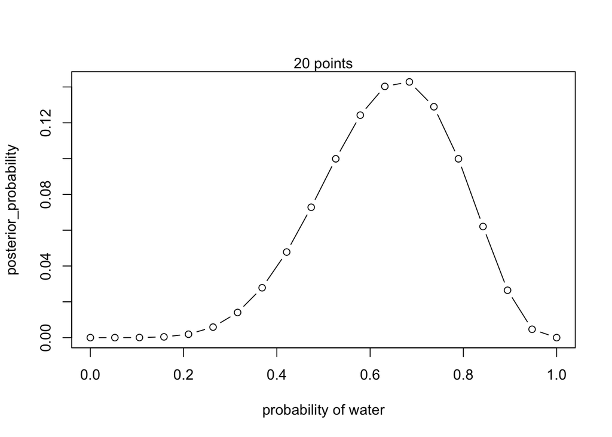

```r
# Grid Approximation

# define grid
p_grid = seq(from = 0, to = 1, length.out=20)

# define prior
prior = rep(1, 20)

# compute likelihood at each value in grid
likelihood = dbinom(6, size = 9, prob = p_grid)

# compute product of likelihood and prior
unstd.posterior = likelihood * prior

# standardize the posterior so it sums to 1
posterior = unstd.posterior / sum(unstd.posterior)

# plot the distribution
plot(p_grid, posterior, type = "b",
     xlab = "probability of water", ylab = "posterior_probability")
mtext("20 points")
```

## Exercises

### Medium

#### 2M1.

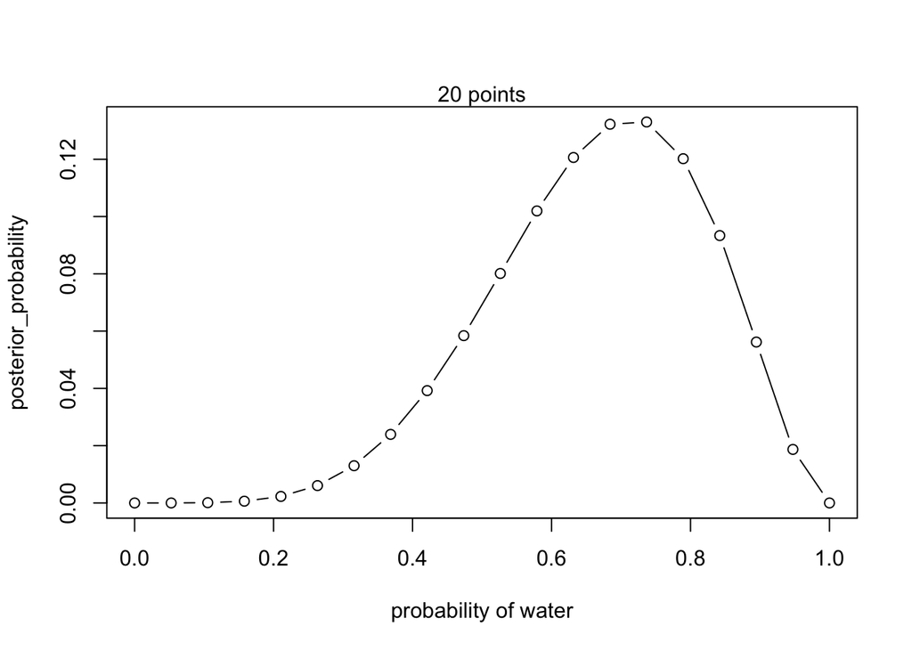

```r
# define grid
p_grid = seq(from = 0, to = 1, length.out=20)

# define prior
prior = rep(1, 20)

# compute likelihood at each value in grid
likelihood = dbinom(5, size = 7, prob = p_grid)
# change to dbinom(3, size = 3
# change to dbinom(3, size = 4
# change to dbinom(5, size = 7

# compute product of likelihood and prior
unstd.posterior = likelihood * prior

# standardize the posterior so it sums to 1
posterior = unstd.posterior / sum(unstd.posterior)

# plot the distribution
plot(p_grid, posterior, type = "b",
     xlab = "probability of water", ylab = "posterior_probability")
mtext("20 points")
```

#### 2M2.

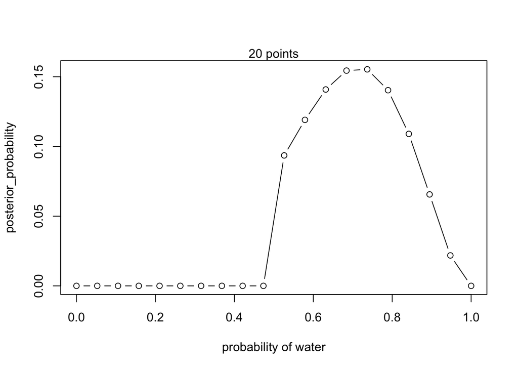

```r
# define grid
p_grid = seq(from = 0, to = 1, length.out=20)

# step prior, which codes our assumption that all probabilities before 0.5 are impossible
prior = ifelse(p_grid < 0.5, 0 , 1)

# compute likelihood at each value in grid
likelihood = dbinom(5, size = 7, prob = p_grid)
# change to dbinom(3, size = 3
# change to dbinom(3, size = 4
# change to dbinom(5, size = 7

# compute product of likelihood and prior
unstd.posterior = likelihood * prior

# standardize the posterior so it sums to 1
posterior = unstd.posterior / sum(unstd.posterior)

# plot the distribution
plot(p_grid, posterior, type = "b",
     xlab = "probability of water", ylab = "posterior_probability")
mtext("20 points")
```

#### 2M3.

```r
# Pr(Earth|Land) = Pr(Land|Earth) * Pr(Earth) / Pr(Land)

answer = 0.3 * 0.5 / ((1 + 0.3) / 2)

answer
```

```
## [1] 0.2307692
```

#### 2M4.

Using the table similar to one on page 25.

*B* - black, *W* - white

| Cards | Ways to produce observation *B* |
| --- | --- |
| BB | 2 |
| BW | 1 |
| WW | 0 |

Total ways to produce observation *B*: 3

Since BB card can produce *B* in two different ways (via each side) out of total possible ways, the probability that the called pulled out was indeed BB is **2/3** or **0.66**.

#### 2M5.

Here we just add another BB card.

*B* - black, *W* - white

| Cards | Ways to produce observation *B* |
| --- | --- |
| BB | 2 |
| BB | 2 |
| BW | 1 |
| WW | 0 |

Total ways to produce observation *B*: 5

Now that we have two BB cards, we simply sum the number ways the can produce observation *B* and divide it by the total number of possible observations of *B*. So **4/5** or **0.8**.

#### 2M6.

Here we add another column to our table - our prior.

*B* - black, *W* - white

| Cards | Ways to produce observation *B* | Prior | Updated count |
| --- | --- | --- | --- |
| BB | 2 | 1 | 2 |
| BW | 1 | 2 | 2 |
| WW | 0 | 3 | 0 |

Total ways to produce observation *B*: 4

So both BW and BB cards are **equally likely** to produce observation *B*.

#### 2M7.

This task is best solved by drawing up the ‘garden of forking paths’ from the beginning of the chapter. Essentially, we count how many ways **each starting card** could have produced observation *W* on the second draw.

Let’s start with BB.

```
## Plot coordinates for graph not supplied! Generating coordinates, see ?coordinates for how to set your own.
```

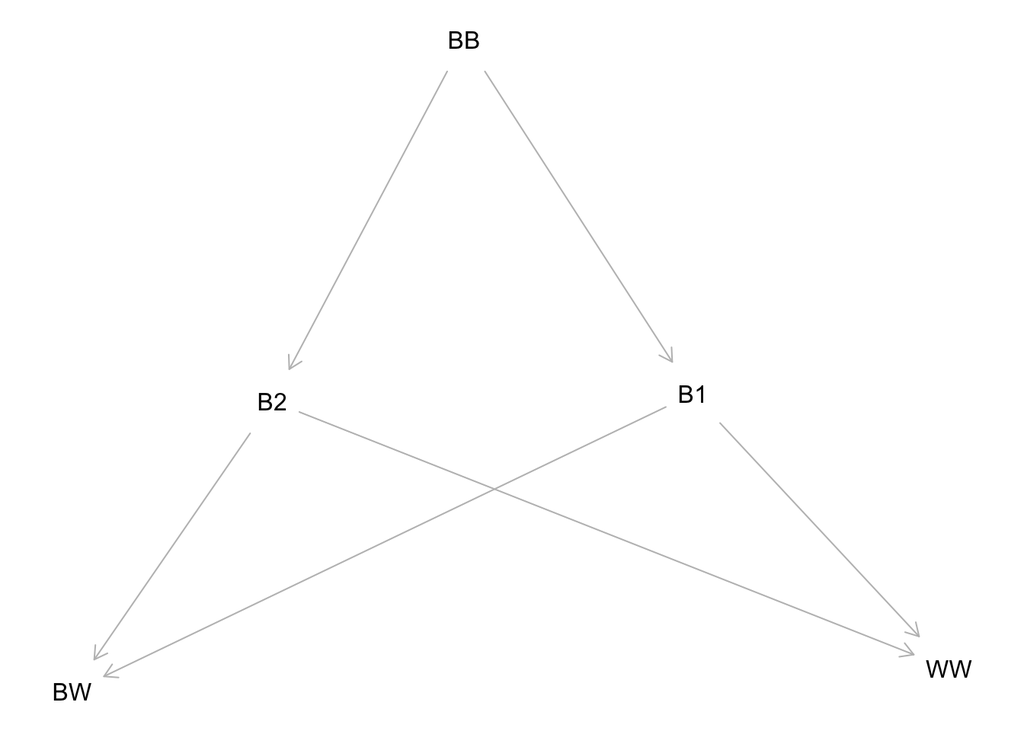

```r
library(dagitty)

# Create a dagitty object
garden <- dagitty("dag {
  BB -> B1
  BB -> B2
  B1 -> BW
  B1 -> WW
  B2 -> BW
  B2 -> WW
}")

# Plot it
plot(garden)
```

As we can see above, if our first card was BB, there are 6 ways the second draw could have been *W* - 3 for one side of BB (B1) and 3 for the other side of BB (B2).

Now let’s assume the first card drawn was BW and count the ways for the second draw to be *W*.

```
## Plot coordinates for graph not supplied! Generating coordinates, see ?coordinates for how to set your own.
```

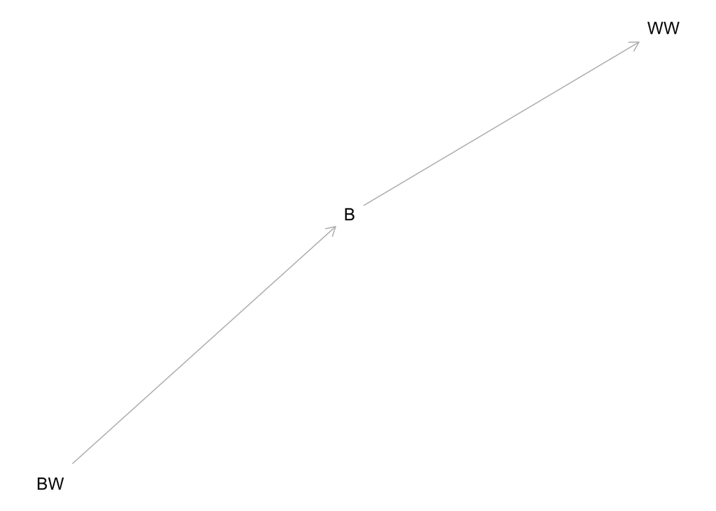

```r
# Create our garden
garden <- dagitty("dag {
  BW -> B
  B -> WW
}")

# Plot it
plot(garden)
```

If the first card was BW, then the only way to get *W* on the second draw is by pulling the WW card out - either of it’s side.

Now we table our findings.

| Cards | Ways to produce observation *W* on second draw |
| --- | --- |
| BB | 6 |
| BW | 2 |
| WW | 0 |

Total ways to produce observation *W* on second draw: 8

Therefore, to get the probability that the first card drawn was BB is **6/8** or **0.75**.